# AR_assignment_2_Staub

Alexander Staub

July 9, 2020

## Question 1

How are the observed firm characteristics distributed across the presence and absence of the treatment? What does this suggest?

### Answer 1

first, create a table of summary statistics with the psych package of the firm characteristic variables x1 to x4. Check whether at least one variable’s mean is significantly different in treatment group compared to control

```
##
##  Descriptive statistics by group
## group: 0
##    vars   n  mean   sd median trimmed  mad   min   max range  skew kurtosis
## x1    1 151  0.05 1.06  -0.27   -0.17 0.54 -0.96  3.38  4.34  1.81     2.62
## x2    2 151  1.40 1.01   1.21    1.31 0.98  0.00  4.09  4.09  0.68    -0.31
## x3    3 151 -0.07 1.01  -0.06   -0.07 1.22 -2.03  1.66  3.69 -0.11    -0.90
## x4    4 151  7.18 1.15   7.12    7.16 0.90  3.94 10.80  6.86  0.21     1.01
##      se
## x1 0.09
## x2 0.08
## x3 0.08
## x4 0.09
## ------------------------------------------------------------
## group: 1
##    vars  n  mean   sd median trimmed  mad   min   max range  skew kurtosis   se
## x1    1 79 -0.17 0.70  -0.34   -0.28 0.44 -0.96  2.65  3.61  1.92     4.36 0.08
## x2    2 79  1.36 0.94   1.11    1.23 0.56  0.00  4.24  4.24  1.30     1.45 0.11
## x3    3 79 -0.09 1.03  -0.33   -0.08 1.18 -2.03  1.43  3.46  0.05    -1.26 0.12
## x4    4 79  7.47 1.28   7.68    7.47 0.89  4.28 10.17  5.90 -0.24    -0.13 0.14
```

- calculate the standardized difference to determine which variables show a significant imbalance between control and treatment as well as whether at least one of the variables is creating imbalance with an omnibus Xi-squared test (see Hansen and Bowers, 2008)

```r
library(RItools)
#indices of covariance imbalances
treated<-(df_raw$D==1)
cov<-df_raw[,2:5]
std.diff<-apply(cov,2,function(x) 100*(mean(x[treated])- mean(x[!treated]))/(sqrt(0.5*(var(x[treated])+var(x[!treated])))))
abs(std.diff)
```

```
##        x1        x2        x3        x4
## 24.895734  4.126123  2.134582 23.916607
```

```r
#check whether at least one of the variables is causing statistical imbalance with a chi-squared test
xBalance(D ~ x1 + x2 + x3 + x4, data = df_raw, report = c("chisquare.test"))
```

```
## ---Overall Test---
##         chisquare df p.value
## unstrat      6.49  4   0.166
## ---
## Signif. codes:  0 '***' 0.001 '** ' 0.01 '*  ' 0.05 '.  ' 0.1 '   ' 1
```

As one can see in the ouput above, means differ among the firm characteristic variables, however not dramatically. looking at the standardized differences, no absolute scores are higher than 25% (set as suspect limit by Stuart and Rubin, 2008) and the chi squared test does not imply significance at the 0.95 significance level. THis implies that there is some issue in terms of covariate difference between treatment and control group, but it may not severely impact inferences that can be made

## Question 2

Use propensity scores to match the presence of the treatment (‘treatment group’) to the absence of the treatment (‘control group’) based on the observed firm characteristics (Note: make sure that the maximum difference in the probability of treatment between the treatment and matched control is less than or equal to 1 percentage point)

1. How are the observed firm characteristics distributed across the presence and absence of the treatment for this matched sample?
2. What is the difference in the outcome variable Y between the presence and absence of the treatment for the propensity-matched sample?

### Answer 2

First calculate the propensity score for the two groups with a logistic regression using the firm characteristic variables as matching variables. As I am not able to find any R documentation on setting a minimum distance in propensity score for matching individuals, I will run 3 matching procedures and use the matching procedure which provides the best support. All are estimated without replacement and 1:1 * 1. Nearest Neighbour greedy * 2. Optimal * 3. Nearest Neighbour Caliper, setting caliper at 0.25 as this seems to be the standard (Rosenbaum and Robin, 1985)

```r
library(MatchIt)
library(stats)

#matching with nearest neighbour, greedy, no replacement
matched_nn_df <- matchit(D~ x1 + x2 + x3 + x4, method = "nearest", data = df_raw)

#matching with nearest neighbour, no replacement
matched_opt_df <- matchit(D ~ x1 + x2 + x3 + x4, method = "optimal", data = df_raw)

#matching with nearest neighbour caliper, no replacement
matched_calip_df <- matchit(D ~ x1 + x2 + x3 + x4, method ="nearest", caliper = 0.25, data = df_raw)
```

based on the mean difference and qq Max values after the different matching procedures, optimal matching was chosen as the best method for reducing mean difference (check appendix item A to inspect the summary tables for matching procedure).

below find plots of the changes in propensity score distribution before and after using optimal matching procedure

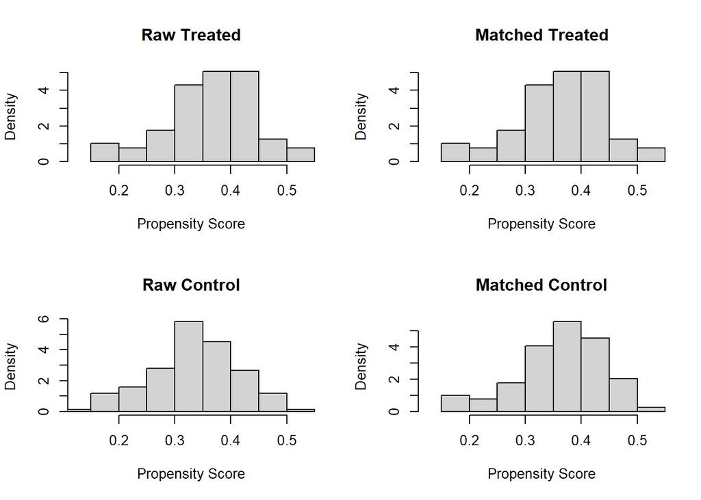

```r
plot(matched_opt_df, type = "hist")
```

1. below, find the covariate distribution in presence and absence of treatment with the optimally matched data

```r
#get the matched data
df_opt_match <- match.data(matched_opt_df)

#run the summary of the matched data
psych::describeBy(df_opt_match[,2:5], group = df_opt_match$D)
```

```
##
##  Descriptive statistics by group
## group: 0
##    vars  n  mean   sd median trimmed  mad   min   max range  skew kurtosis   se
## x1    1 79 -0.15 0.87  -0.36   -0.31 0.43 -0.96  3.38  4.34  2.18     5.04 0.10
## x2    2 79  1.33 1.06   1.12    1.22 1.12  0.00  3.80  3.80  0.82    -0.29 0.12
## x3    3 79  0.02 1.02   0.27    0.03 1.12 -2.03  1.66  3.69 -0.19    -0.99 0.11
## x4    4 79  7.46 1.21   7.27    7.45 0.86  4.19 10.80  6.61  0.20     0.84 0.14
## ------------------------------------------------------------
## group: 1
##    vars  n  mean   sd median trimmed  mad   min   max range  skew kurtosis   se
## x1    1 79 -0.17 0.70  -0.34   -0.28 0.44 -0.96  2.65  3.61  1.92     4.36 0.08
## x2    2 79  1.36 0.94   1.11    1.23 0.56  0.00  4.24  4.24  1.30     1.45 0.11
## x3    3 79 -0.09 1.03  -0.33   -0.08 1.18 -2.03  1.43  3.46  0.05    -1.26 0.12
## x4    4 79  7.47 1.28   7.68    7.47 0.89  4.28 10.17  5.90 -0.24    -0.13 0.14
```

after matching, the distribution has improved markedly across all covariates comparing absence and presence of treatment, apart for covariate x3.

2. find below a t-test to compare the difference in the outcome variable with the matched data

```r
#t test with matched data
t.test(df_opt_match$y ~ df_opt_match$D, conf.level = 0.95)
```

```
##
##  Welch Two Sample t-test
##
## data:  df_opt_match$y by df_opt_match$D
## t = -1.0721, df = 155.93, p-value = 0.2853
## alternative hypothesis: true difference in means is not equal to 0
## 95 percent confidence interval:
##  -0.13452071  0.03986742
## sample estimates:
## mean in group 0 mean in group 1
##       0.7979747       0.8453013
```

```r
#unmatched
t.test(df_raw$y ~ df_raw$D, conf.level = 0.95)
```

```
##
##  Welch Two Sample t-test
##
## data:  df_raw$y by df_raw$D
## t = -2.0047, df = 168.71, p-value = 0.04659
## alternative hypothesis: true difference in means is not equal to 0
## 95 percent confidence interval:
##  -0.158916785 -0.001222296
## sample estimates:
## mean in group 0 mean in group 1
##       0.7652318       0.8453013
```

according to the t-test above, the difference in mean outcomes with the matched data is not significant at the 0.95 confidence level, while there is a signficant difference at the 0.95 level for the unmatched data.

## Quesiton 3

Use propensity scores to create a sample that is on “common support” and estimate the treatment effect using a regression with covariates.

### answer 3

run a matching procedure that establishes common support. Herein, nearest neighbour greedy, 1:1 without replacement, discarding observations that fall outside the area of common support is implemented

```r
#estimate the model around common support
matched_nn_cs_df <- matchit(D ~ x1 + x2 + x3 + x4, data = df_raw, discard="both", type="nearest", m.order="largest")

#save the matched data
df_nn_cs_match <- match.data(matched_nn_cs_df)
```

The treatment effect is estimated below

```r
summary(lm(y~D+x1+x2+x3+x4, data = df_nn_cs_match))
```

```
##
## Call:
## lm(formula = y ~ D + x1 + x2 + x3 + x4, data = df_nn_cs_match)
##
## Residuals:
##      Min       1Q   Median       3Q      Max
## -0.67801 -0.12313 -0.02976  0.11440  0.60106
##
## Coefficients:
##             Estimate Std. Error t value Pr(>|t|)
## (Intercept)  0.03545    0.14526   0.244  0.80753
## D            0.06898    0.03917   1.761  0.08031 .
## x1           0.07928    0.02644   2.999  0.00318 **
## x2          -0.01762    0.02422  -0.727  0.46813
## x3           0.05338    0.01931   2.765  0.00642 **
## x4           0.10424    0.02132   4.890 2.59e-06 ***
## ---
## Signif. codes:  0 '***' 0.001 '**' 0.01 '*' 0.05 '.' 0.1 ' ' 1
##
## Residual standard error: 0.2422 on 148 degrees of freedom
## Multiple R-squared:  0.2131, Adjusted R-squared:  0.1865
## F-statistic: 8.014 on 5 and 148 DF,  p-value: 1.035e-06
```

estimating the treatment effect with the matched sample leads to an insignificant treatment effect (at the 0.95 significance level)

## Question 4

Use propensity scores to weight observations and estimate the average treatment effect (ATE) and the treatment on the treated (TOT).

### answer 4

find below the average treatment effect on the treated using propensity score weighting

```r
if (!require(survey)) install.packages("survey"); library(survey)

#trying weightit package
if (!require(WeightIt)) install.packages("WeightIt"); library(WeightIt)

W.out <- weightit(D ~ x1 + x2 + x3 + x4,
        data = df_raw, estimand = "ATT", method = "ps")

#check the summary
summary(W.out)
```

```
##                  Summary of weights
##
## - Weight ranges:
##
##            Min                                  Max
## treated 1.0000                            || 1.0000
## control 0.1434 |---------------------------| 1.0809
##
## - Units with 5 greatest weights by group:
##
##               1      2      3      4      5
##  treated      1      1      1      1      1
##             203    202    135    127     66
##  control 0.9061 0.9325 0.9496 0.9594 1.0809
##
## - Weight statistics:
##
##         Coef of Var   MAD Entropy # Zeros
## treated       0.000 0.000   0.000       0
## control       0.348 0.272  -0.592       0
## overall       0.396 0.357  -0.295       0
##
## - Effective Sample Sizes:
##
##            Control Treated
## Unweighted 151.000      79
## Weighted   134.795      79
```

```r
#get the weights
weights <- svydesign(ids = ~1, weights = W.out$weights, data = df_raw)

#run weighted regression
model_w_att <- svyglm(y ~ D + x1 + x2 + x3 + x4, design = weights)
summary(model_w_att)
```

```
##
## Call:
## svyglm(formula = y ~ D + x1 + x2 + x3 + x4, design = weights)
##
## Survey design:
## svydesign(ids = ~1, weights = W.out$weights, data = df_raw)
##
## Coefficients:
##              Estimate Std. Error t value Pr(>|t|)
## (Intercept) -0.002343   0.131370  -0.018 0.985789
## D            0.068633   0.033580   2.044 0.042135 *
## x1           0.091145   0.030025   3.036 0.002684 **
## x2          -0.005532   0.016458  -0.336 0.737071
## x3           0.065599   0.018075   3.629 0.000352 ***
## x4           0.108209   0.019591   5.523 9.19e-08 ***
## ---
## Signif. codes:  0 '***' 0.001 '**' 0.01 '*' 0.05 '.' 0.1 ' ' 1
##
## (Dispersion parameter for gaussian family taken to be 0.05946896)
##
## Number of Fisher Scoring iterations: 2
```

using the weighting procedure, the treatement effect on the treated is significant at the 0.95 significance level

```r
#estimate the propensity scores
ps_ate <- glm(D ~ x1 + x2 + x3 + x4, data = df_raw, family = "binomial")
#attach ps scores to the dataset
df_raw$psvalues <- predict(ps_ate, type = "response")
#extract the weights
df_raw$w_ate <- ifelse(df_raw$D == 1, 1/df_raw$psvalues, 1/(1-df_raw$psvalues))
#calculate the model
model_w_ate <- lm(y ~ D + x1 + x2 + x3 + x4, data = df_raw, weights = (w_ate))
summary(model_w_ate)
```

```
##
## Call:
## lm(formula = y ~ D + x1 + x2 + x3 + x4, data = df_raw, weights = (w_ate))
##
## Weighted Residuals:
##      Min       1Q   Median       3Q      Max
## -0.96638 -0.19015 -0.02381  0.17382  1.16330
##
## Coefficients:
##              Estimate Std. Error t value Pr(>|t|)
## (Intercept) 0.0768505  0.1142647   0.673 0.501917
## D           0.0745941  0.0334123   2.233 0.026569 *
## x1          0.0928121  0.0202039   4.594 7.26e-06 ***
## x2          0.0003638  0.0191035   0.019 0.984824
## x3          0.0625232  0.0164037   3.812 0.000179 ***
## x4          0.0960117  0.0166828   5.755 2.83e-08 ***
## ---
## Signif. codes:  0 '***' 0.001 '**' 0.01 '*' 0.05 '.' 0.1 ' ' 1
##
## Residual standard error: 0.3586 on 224 degrees of freedom
## Multiple R-squared:  0.2387, Adjusted R-squared:  0.2217
## F-statistic: 14.05 on 5 and 224 DF,  p-value: 5.988e-12
```

The ATE using propensity score weights is also significant at the 0.95 significance level

In summary, using matching leads to a lower adjusted R-sqaured as well as an insignificant treatment effect (at least at 0.95 level) as well as a lower adjusted R-squared

## Question 5

Use entropy balancing to estimate the treatment effect of D on the outcome Y?

- 1. Use as balance constraints the first moment (mean).
- 5.i.1. How are the observed firm characteristics distributed across the presence and absence of the treatment for this matched sample?
- 5.i.2. What is the difference in the outcome variable Y between the presence and absence of the treatment for the propensity-matched sample?
- 2. Use as balance constraints the first and second moment (mean and variance).
- 5.ii.1. How are the observed firm characteristics distributed across the presence and absence of the treatment for this matched sample
- 5.ii.2. What is the difference in the outcome variable Y between the presence and absence of the treatment for the propensity-matched sample?

### answer 5

5.i.1 run the entropy balancing and check the balance of the observed firm characteristics

```r
if (!require(ebal)) install.packages("ebal"); library(ebal)
library(cobalt)
#run the entropy balancing on the first moment
W.out.ebal.1 <- weightit(D ~ x1 + x2 + x3 + x4,
        data = df_raw, estimand = "ATT", method = "ebal", moments = 1)

#check the balance
bal.tab(W.out.ebal.1, m.threshold = 0.05, disp.v.ratio = T)
```

```
## Call
##  weightit(formula = D ~ x1 + x2 + x3 + x4, data = df_raw, method = "ebal", estimand = "ATT", moments = 1)
##
## Balance Measures
##       Type Diff.Adj     M.Threshold V.Ratio.Adj
## x1 Contin.  -0.0078 Balanced, <0.05      0.6710
## x2 Contin.   0.0003 Balanced, <0.05      0.8058
## x3 Contin.   0.0005 Balanced, <0.05      0.9754
## x4 Contin.   0.0028 Balanced, <0.05      1.2532
##
## Balance tally for mean differences
##                     count
## Balanced, <0.05         4
## Not Balanced, >0.05     0
##
## Variable with the greatest mean difference
##  Variable Diff.Adj     M.Threshold
##        x1  -0.0078 Balanced, <0.05
##
## Effective sample sizes
##            Control Treated
## Unadjusted  151.00      79
## Adjusted    132.18      79
```

one can see that the entropy balancing has yielded very good balance for the covariates across the board

5.i.2 estimate the model with the reweighted data

```r
#get the weights
weights.ebal.1 <- svydesign(ids = ~1, weights = W.out.ebal.1$weights, data = df_raw)

#run weighted regression
model_w_ebal_1 <- svyglm(y ~ D + x1 + x2 + x3 + x4, design = weights.ebal.1)
summary(model_w_ebal_1)
```

```
##
## Call:
## svyglm(formula = y ~ D + x1 + x2 + x3 + x4, design = weights.ebal.1)
##
## Survey design:
## svydesign(ids = ~1, weights = W.out.ebal.1$weights, data = df_raw)
##
## Coefficients:
##               Estimate Std. Error t value Pr(>|t|)
## (Intercept) -0.0005917  0.1320828  -0.004 0.996430
## D            0.0683834  0.0335160   2.040 0.042491 *
## x1           0.0880804  0.0305846   2.880 0.004364 **
## x2          -0.0036523  0.0163980  -0.223 0.823953
## x3           0.0673504  0.0180280   3.736 0.000237 ***
## x4           0.1076164  0.0196420   5.479 1.15e-07 ***
## ---
## Signif. codes:  0 '***' 0.001 '**' 0.01 '*' 0.05 '.' 0.1 ' ' 1
##
## (Dispersion parameter for gaussian family taken to be 0.05966721)
##
## Number of Fisher Scoring iterations: 2
```

using the entropy balancing method fixed on 1st moment, the difference in outcome between treatment and non-treatment ist 0.07 at the 0.95 significance level

5.i.2 estimate the weights for entropy balancing across 1st and 2nd moment

```r
#run the entropy balancing on the first moment
W.out.ebal.2 <- weightit(D ~ x1 + x2 + x3 + x4,
        data = df_raw, estimand = "ATT", method = "ebal", moments = 2)

#check the balance
bal.tab(W.out.ebal.2, m.threshold = 0.05, disp.v.ratio = T)
```

```
## Call
##  weightit(formula = D ~ x1 + x2 + x3 + x4, data = df_raw, method = "ebal", estimand = "ATT", moments = 2)
##
## Balance Measures
##       Type Diff.Adj     M.Threshold V.Ratio.Adj
## x1 Contin.  -0.0078 Balanced, <0.05      0.6710
## x2 Contin.   0.0003 Balanced, <0.05      0.8058
## x3 Contin.   0.0005 Balanced, <0.05      0.9754
## x4 Contin.   0.0028 Balanced, <0.05      1.2532
##
## Balance tally for mean differences
##                     count
## Balanced, <0.05         4
## Not Balanced, >0.05     0
##
## Variable with the greatest mean difference
##  Variable Diff.Adj     M.Threshold
##        x1  -0.0078 Balanced, <0.05
##
## Effective sample sizes
##            Control Treated
## Unadjusted  151.00      79
## Adjusted    132.18      79
```

as in the prior example, the entropy balancing yields good balancing

5.ii.2 estimate the model with the reweighted data

```r
#get the weights
weights.ebal.2 <- svydesign(ids = ~1, weights = W.out.ebal.2$weights, data = df_raw)

#run weighted regression
model_w_ebal_2 <- svyglm(y ~ D + x1 + x2 + x3 + x4, design = weights.ebal.2)
summary(model_w_ebal_2)
```

```
##
## Call:
## svyglm(formula = y ~ D + x1 + x2 + x3 + x4, design = weights.ebal.2)
##
## Survey design:
## svydesign(ids = ~1, weights = W.out.ebal.2$weights, data = df_raw)
##
## Coefficients:
##               Estimate Std. Error t value Pr(>|t|)
## (Intercept) -0.0005917  0.1320828  -0.004 0.996430
## D            0.0683834  0.0335160   2.040 0.042491 *
## x1           0.0880804  0.0305846   2.880 0.004364 **
## x2          -0.0036523  0.0163980  -0.223 0.823953
## x3           0.0673504  0.0180280   3.736 0.000237 ***
## x4           0.1076164  0.0196420   5.479 1.15e-07 ***
## ---
## Signif. codes:  0 '***' 0.001 '**' 0.01 '*' 0.05 '.' 0.1 ' ' 1
##
## (Dispersion parameter for gaussian family taken to be 0.05966721)
##
## Number of Fisher Scoring iterations: 2
```

the results for using the 1st and 2nd moment yield the same results, however it may be the case that the entropy balancing moment selection in the package I am using is not doing what I expect it to do. However, I am not able to find any reliable documentation on an R package for entropy balancing to solve the problem set as set out in this assignment.

## Question 6

Provide an overview table with all of the above treatment effects, as well as the treatment effect of the “regular regression” that was part of the Session 1 assignment.

## answer 6

- Treatment effect A2 assignement 1: 0.0697 at sig level 0.9
- Treatment effect A3 assignement 1: (w. industry): 0.0943 at sig level 0.9
- Treatment effect A4 assignement 1: (w. clustered SE): 0.0943 insignificant
- Treatment effect A3 assignemnet 2: (w. matching and common support): 0.0690 at sig level 0.9
- ATT effect A4 assignment 2: (w. ps reweighting): 0.0686 at sig level 0.95
- ATE effect A4 assignment 2: (w. ps reweighting): 0.0746 at sig level 0.95
- Treatment effect A5 assignment 2: (entropy balancing 1st moment): 0.0684 at sig level 0.95
- Treatment effect A5 assignemnet 2: (entropy balancing 2nd moment): 0.0684 at sig level 0.95

## Appendix

Appendix A: Summaries of the matching procdeures in question 2

nearest neighbour greedy

```r
summary(matched_nn_df, standardize = T)
```

```
##
## Call:
## matchit(formula = D ~ x1 + x2 + x3 + x4, data = df_raw, method = "nearest")
##
## Summary of balance for all data:
##          Means Treated Means Control SD Control Std. Mean Diff. eCDF Med
## distance        0.3630        0.3332     0.0787          0.3691   0.1047
## x1             -0.1734        0.0505     1.0628         -0.3205   0.0482
## x2              1.3611        1.4013     1.0097         -0.0429   0.0389
## x3             -0.0943       -0.0725     1.0140         -0.0212   0.0318
## x4              7.4719        7.1818     1.1466          0.2274   0.0888
##          eCDF Mean eCDF Max
## distance    0.1107   0.2239
## x1          0.0485   0.1086
## x2          0.0523   0.1311
## x3          0.0407   0.1153
## x4          0.1157   0.3476
##
##
## Summary of balance for matched data:
##          Means Treated Means Control SD Control Std. Mean Diff. eCDF Med
## distance        0.3630        0.3592     0.0769          0.0477   0.0127
## x1             -0.1734       -0.1541     0.8792         -0.0276   0.0380
## x2              1.3611        1.2200     0.9461          0.1504   0.0380
## x3             -0.0943        0.0392     0.9864         -0.1298   0.0633
## x4              7.4719        7.3181     1.0559          0.1206   0.0886
##          eCDF Mean eCDF Max
## distance    0.0193   0.0886
## x1          0.0351   0.0759
## x2          0.0440   0.1519
## x3          0.0613   0.1519
## x4          0.1036   0.2911
##
## Percent Balance Improvement:
##          Std. Mean Diff. eCDF Med eCDF Mean eCDF Max
## distance         87.0773  87.9103   82.5554  60.4268
## x1               91.4027  21.2858   27.6062  30.0386
## x2             -250.9084   2.3707   15.8157 -15.8568
## x3             -512.2454 -99.2084  -50.3525 -31.7818
## x4               46.9663   0.1889   10.4794  16.2325
##
## Sample sizes:
##           Control Treated
## All           151      79
## Matched        79      79
## Unmatched      72       0
## Discarded       0       0
```

optimal matching

```r
summary(matched_opt_df, standardize = T)
```

```
##
## Call:
## matchit(formula = D ~ x1 + x2 + x3 + x4, data = df_raw, method = "optimal")
##
## Summary of balance for all data:
##          Means Treated Means Control SD Control Std. Mean Diff. eCDF Med
## distance        0.3630        0.3332     0.0787          0.3691   0.1047
## x1             -0.1734        0.0505     1.0628         -0.3205   0.0482
## x2              1.3611        1.4013     1.0097         -0.0429   0.0389
## x3             -0.0943       -0.0725     1.0140         -0.0212   0.0318
## x4              7.4719        7.1818     1.1466          0.2274   0.0888
##          eCDF Mean eCDF Max
## distance    0.1107   0.2239
## x1          0.0485   0.1086
## x2          0.0523   0.1311
## x3          0.0407   0.1153
## x4          0.1157   0.3476
##
##
## Summary of balance for matched data:
##          Means Treated Means Control SD Control Std. Mean Diff. eCDF Med
## distance        0.3630        0.3617     0.0788          0.0159   0.0127
## x1             -0.1734       -0.1461     0.8736         -0.0391   0.0253
## x2              1.3611        1.3292     1.0619          0.0340   0.0380
## x3             -0.0943        0.0173     1.0202         -0.1085   0.0380
## x4              7.4719        7.4624     1.2123          0.0074   0.0506
##          eCDF Mean eCDF Max
## distance    0.0137   0.0633
## x1          0.0299   0.0886
## x2          0.0486   0.1392
## x3          0.0543   0.1646
## x4          0.0677   0.2405
##
## Percent Balance Improvement:
##          Std. Mean Diff. eCDF Med eCDF Mean eCDF Max
## distance         95.6960  87.9103   87.6223  71.7334
## x1               87.7906  47.5239   38.2302  18.3784
## x2               20.6853   2.3707    7.1830  -6.2020
## x3             -411.7873 -19.5251  -33.2287 -42.7636
## x4               96.7241  42.9651   41.4966  30.8008
##
## Sample sizes:
##           Control Treated
## All           151      79
## Matched        79      79
## Unmatched      72       0
## Discarded       0       0
```

nearest neighbour caliper

```r
summary(matched_calip_df, standardize = T)
```

```
##
## Call:
## matchit(formula = D ~ x1 + x2 + x3 + x4, data = df_raw, method = "nearest",
##     caliper = 0.25)
##
## Summary of balance for all data:
##          Means Treated Means Control SD Control Std. Mean Diff. eCDF Med
## distance        0.3630        0.3332     0.0787          0.3691   0.1047
## x1             -0.1734        0.0505     1.0628         -0.3205   0.0482
## x2              1.3611        1.4013     1.0097         -0.0429   0.0389
## x3             -0.0943       -0.0725     1.0140         -0.0212   0.0318
## x4              7.4719        7.1818     1.1466          0.2274   0.0888
##          eCDF Mean eCDF Max
## distance    0.1107   0.2239
## x1          0.0485   0.1086
## x2          0.0523   0.1311
## x3          0.0407   0.1153
## x4          0.1157   0.3476
##
##
## Summary of balance for matched data:
##          Means Treated Means Control SD Control Std. Mean Diff. eCDF Med
## distance        0.3589        0.3563     0.0747          0.0317   0.0260
## x1             -0.1580       -0.1543     0.8350         -0.0053   0.0260
## x2              1.3700        1.2331     0.9525          0.1458   0.0390
## x3             -0.1089        0.0328     1.0297         -0.1378   0.0519
## x4              7.4250        7.2875     1.0195          0.1078   0.0909
##          eCDF Mean eCDF Max
## distance    0.0284   0.0909
## x1          0.0341   0.0909
## x2          0.0409   0.1688
## x3          0.0647   0.1688
## x4          0.0998   0.2987
##
## Percent Balance Improvement:
##          Std. Mean Diff. eCDF Med eCDF Mean eCDF Max
## distance         91.4189  75.1926   74.3228  59.3989
## x1               98.3471  46.1609   29.5858  16.2583
## x2             -240.3114  -0.1651   21.7252 -28.7715
## x3             -550.1509 -63.5062  -58.8404 -46.4718
## x4               52.6026  -2.4036   13.7852  14.0567
##
## Sample sizes:
##           Control Treated
## All           151      79
## Matched        77      77
## Unmatched      74       2
## Discarded       0       0
```

Appendix B: Summary of nearest neighbour matching, discarding elements outside of common support

```r
summary(matched_nn_cs_df)
```

```
##
## Call:
## matchit(formula = D ~ x1 + x2 + x3 + x4, data = df_raw, discard = "both",
##     type = "nearest", m.order = "largest")
##
## Summary of balance for all data:
##          Means Treated Means Control SD Control Mean Diff eQQ Med eQQ Mean
## distance        0.3630        0.3332     0.0787    0.0298  0.0311   0.0311
## x1             -0.1734        0.0505     1.0628   -0.2239  0.0525   0.2339
## x2              1.3611        1.4013     1.0097   -0.0402  0.1828   0.1984
## x3             -0.0943       -0.0725     1.0140   -0.0218  0.1884   0.1572
## x4              7.4719        7.1818     1.1466    0.2901  0.3967   0.4011
##          eQQ Max
## distance  0.0530
## x1        1.7006
## x2        0.6917
## x3        0.3953
## x4        0.7560
##
##
## Summary of balance for matched data:
##          Means Treated Means Control SD Control Mean Diff eQQ Med eQQ Mean
## distance        0.3587        0.3560     0.0748    0.0026  0.0022   0.0035
## x1             -0.1560       -0.1319     0.8971   -0.0241  0.0611   0.1212
## x2              1.3562        1.2540     0.9404    0.1021  0.1828   0.1849
## x3             -0.0908        0.0329     1.0066   -0.1236  0.2131   0.2024
## x4              7.4131        7.3171     1.0283    0.0960  0.4057   0.3748
##          eQQ Max
## distance  0.0164
## x1        0.9650
## x2        1.0059
## x3        0.6407
## x4        1.0195
##
## Percent Balance Improvement:
##          Mean Diff.  eQQ Med eQQ Mean  eQQ Max
## distance    91.1634  92.7716  88.7790  69.0527
## x1          89.2470 -16.3959  48.1904  43.2577
## x2        -153.9086   0.0000   6.8188 -45.4169
## x3        -467.0441 -13.1125 -28.7561 -62.0924
## x4          66.8951  -2.2726   6.5507 -34.8570
##
## Sample sizes:
##           Control Treated
## All           151      79
## Matched        77      77
## Unmatched      72       0
## Discarded       2       2
```

A work by [Alexander Staub](https://github.com/deskreject/)

*alexander.staub@wu.ac.at*